# Maps from ggmap, some code

Trevor Faske

This Rmarkdown is a makes various state or google map forms. Has code to download various map types, crop, color by continuous or discrete variables, and label points. No where near comprehensive, just the basics.

### Loading packages

```r
library(tidyverse)
library(ggrepel)

#remotes::install_github("dkahle/ggmap")

library(ggmap)

library(ggsci)
library('wesanderson')
library(scales)
```

# Map using state data from map_data()

Tons of options built into ggmap to get data for various countries / states

### Make map of US by states

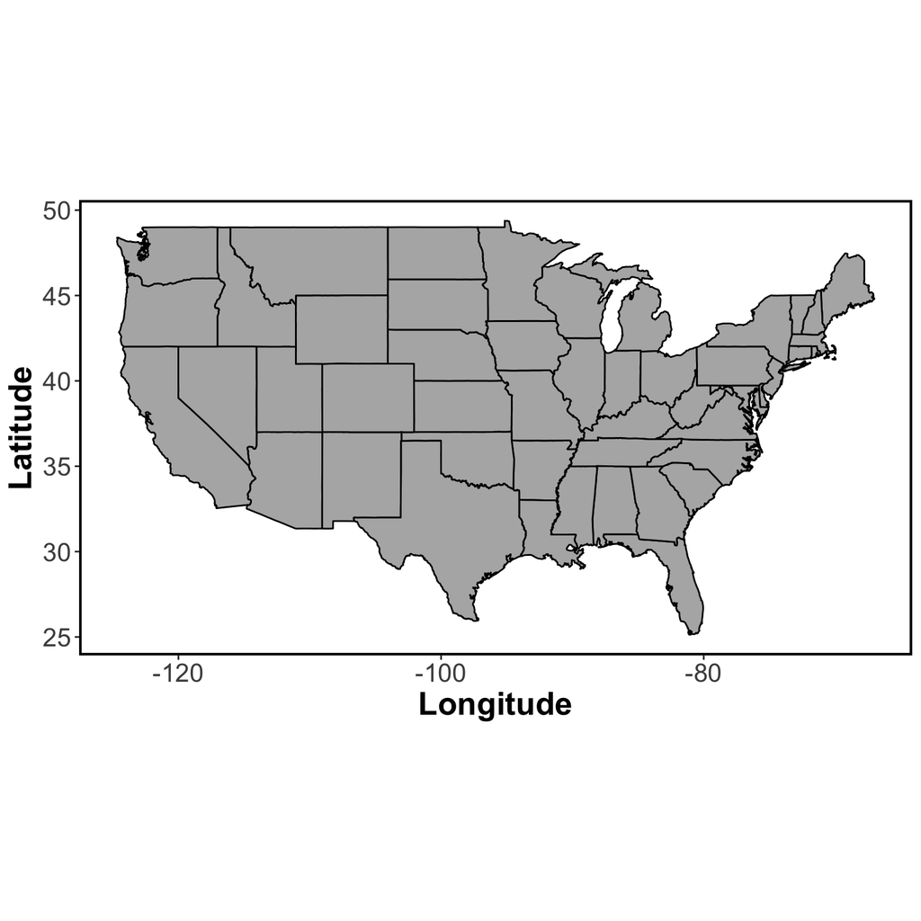

```r
states <- map_data('state')

states_map <- ggplot() +
  geom_polygon(data=states,aes(x = long,y = lat,group = group),
               fill='grey70',color = "black") +
  coord_fixed(1.3) + #this adjusts lat long ratio
  xlab("Longitude") + ylab("Latitude") + theme_bw() +
  theme(axis.title = element_text(size=20,face = 'bold'),
        axis.text = element_text(size=16),
        legend.position = 'none',
        legend.title = element_text(size=18,face = 'bold'),
        panel.border = element_rect(size = 1.5, colour = "black"),
        legend.text = element_text(size=18),
        panel.grid.major = element_blank(),
        panel.grid.minor = element_blank())
states_map
```

### Make make of select states and add colour

```r
states <- map_data('state')

select_states <- c('california', 'oregon','nevada','utah','arizona','montana',
                   'washington','wyoming','idaho','new mexico','colorado')
west <-  states[which(states$region %in% select_states),]
```

**Picking colors**: 11 states so need 11 colours. ggsci package is nice. npg only has 10 so use that then and one more

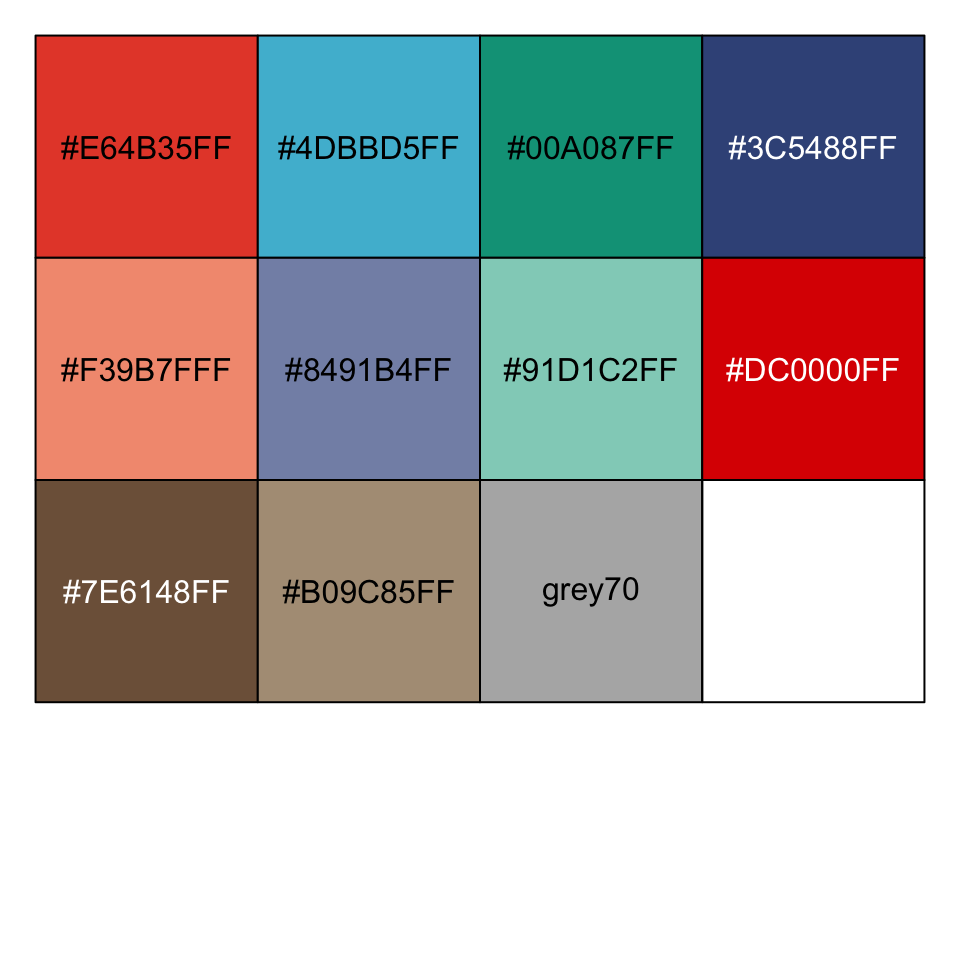

```r
colWest <- c(pal_npg()(10)[1:10],'grey70')
show_col(colWest)
```

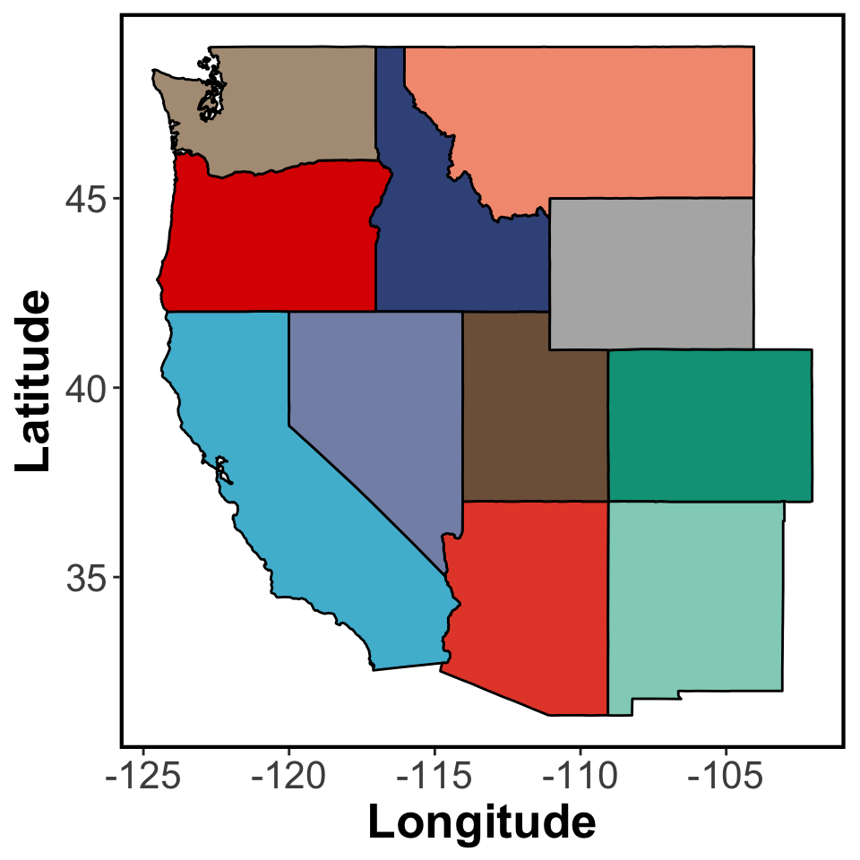

```r
west_map <- ggplot() +
  geom_polygon(data=west,aes(x = long,y = lat,fill = region,
                             group = group),color = "black") +
  scale_fill_manual(name='State:',values = colWest) +
  coord_fixed(1.3) +
  xlab("Longitude") + ylab("Latitude") + theme_bw() +
  theme(axis.title = element_text(size=20,face = 'bold'),
        axis.text = element_text(size=16),
        legend.position = 'none',
        legend.title = element_text(size=18,face = 'bold'),
        panel.border = element_rect(size = 1.5, colour = "black"),
        legend.text = element_text(size=18),
        panel.grid.major = element_blank(),
        panel.grid.minor = element_blank())
west_map
```

# Google Maps

### Load example map data

Metadata: Pop = Population ID Lat = Latitude Long = Longitude State = Abbreviated State Elevation = Elevation (m)

```r
data <- read.csv('ggmap_data.csv')

range(data$Long)
```

```
## [1] -122.0870 -106.4966
```

```r
range(data$Lat)
```

```
## [1] 34.32487 46.47515
```

### stadiamaps

**NOTE:** You have to get an API key. It is free but I think you need a credit card. This is a new thing. you have to register with them and get an API key. https://stadiamaps.com/

**Zoom:** increasing zoom will increase resolution but might lose major details. Play with this option depending upon spatial structure of data. Lower zoom will give state lines, higher zoom can give street names.

**bbox:** Use the range of your data to select which range of map

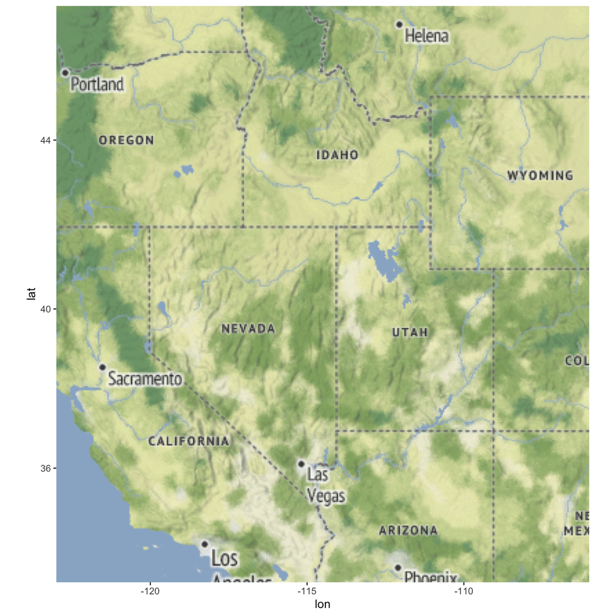

```r
#ggmap::register_stadiamaps('YOUR API CODE HERE')

map <- get_stadiamap(bbox = c(left = -123, bottom = 33,
                              right = -106, top = 47),
                     zoom=5, maptype = 'stamen_terrain')

stadia_map <- ggmap(map); stadia_map
```

### Make stamen map with population labels, colour by discrete

Map will have small white points at exact location with a label that is repelled from points so they don’t overlap. Making the map different sizes will change how cluttered things are. Labels will be filled by state colour.

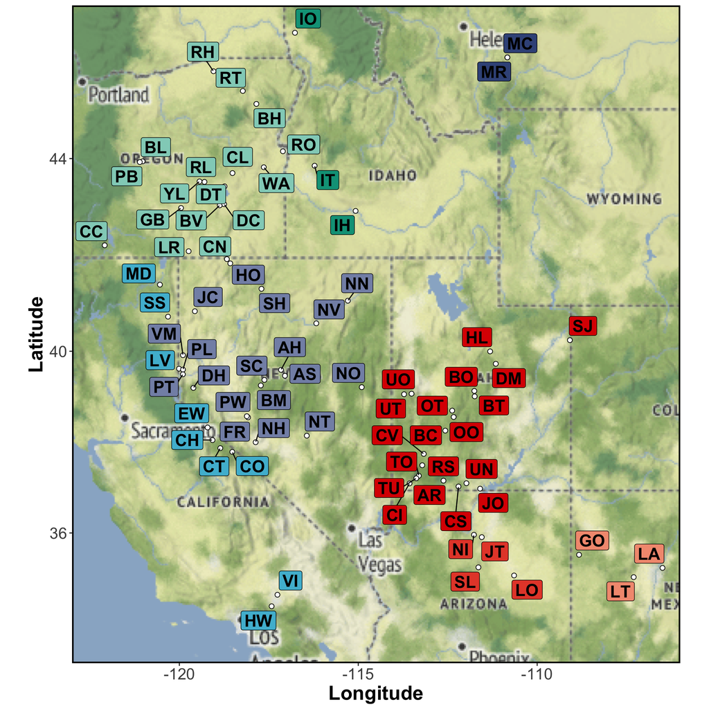

```r
population_map <- ggmap(map) +
  geom_point(data = data, aes(x = Long, y = Lat),
             size=2, colour='black',fill='white',pch=21) +
  geom_label_repel(data = data, aes(x = Long, y = Lat,label = Pop,fill=State),
                   colour = "black", fontface = "bold",size=6) +
  scale_fill_npg(name='State:') +
  xlab("Longitude") + ylab("Latitude") + theme_bw() +
  theme(axis.text = element_text(size=16),
        axis.title = element_text(size = 20, colour="black",face = "bold"),
        panel.border = element_rect(size = 1.5, colour = "black"),
        legend.text = element_text(size = 13),
        legend.position = 'none',
        legend.title = element_text(size = 16, face = "bold"),
        panel.grid = element_blank())
population_map
```

### Make stamen map with population labels, colour by continuous

Same as above but coloured by Elevation. Colour chosen from ‘wesanderson’ package

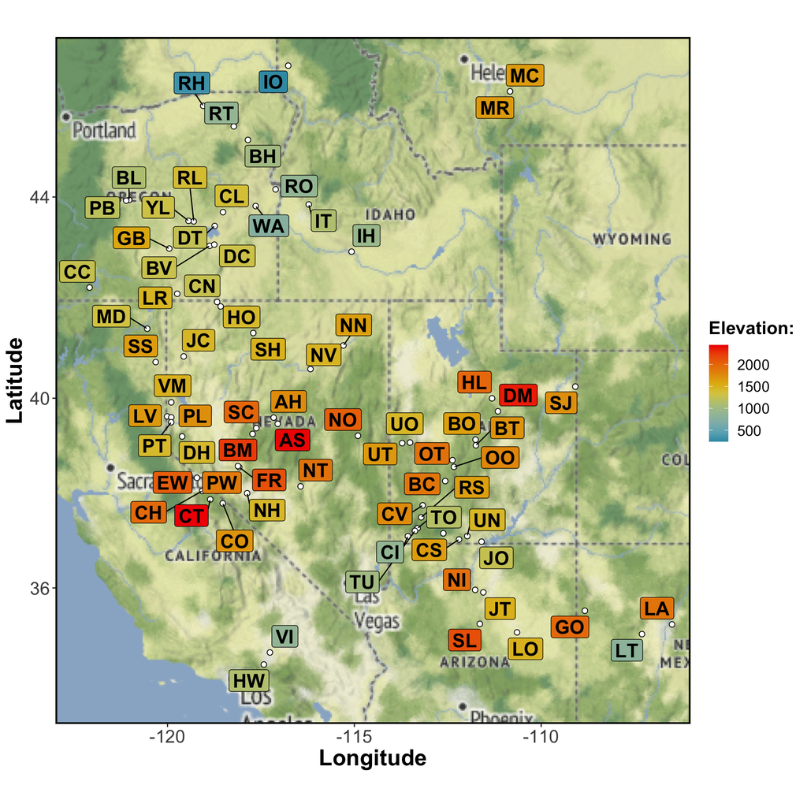

```r
colElev <- wes_palette("Zissou1", 1000, type = "continuous")

elevation_map <- ggmap(map) +
  geom_point(data = data, aes(x = Long, y = Lat),
             size=2, colour='black',fill='white',pch=21) +
  geom_label_repel(data = data, aes(x = Long, y = Lat,label = Pop,fill=Elevation),
                   colour = "black", fontface = "bold",size=6) +
  scale_fill_gradientn(name='Elevation:',colours=colElev) +
  xlab("Longitude") + ylab("Latitude") + theme_bw() +
  theme(axis.text = element_text(size=16),
        axis.title = element_text(size = 20, colour="black",face = "bold"),
        panel.border = element_rect(size = 1.5, colour = "black"),
        legend.text = element_text(size = 13),
        #legend.position = 'none',
        legend.title = element_text(size = 16, face = "bold"),
        panel.grid = element_blank())
elevation_map
```